# l11_es_copia

Seminario de Investigación

Semana 11: Causalidad

Sergi Martínez

smsoler@clio.uc3m.es | Horario de tutorías: martes 10:00–13:00 (previo correo)

## Hoy

23 de noviembre

- Experimentos
  - Conjoint, de laboratorio y de campo
- Nuestra realidad y algunas alternativas

## Repaso del calendario

## Para calentar, interpretemos resultados: La vivienda en España

[interactive chart not shown]

## Para calentar, interpretemos resultados: La vivienda en Alemania

[figure not shown]

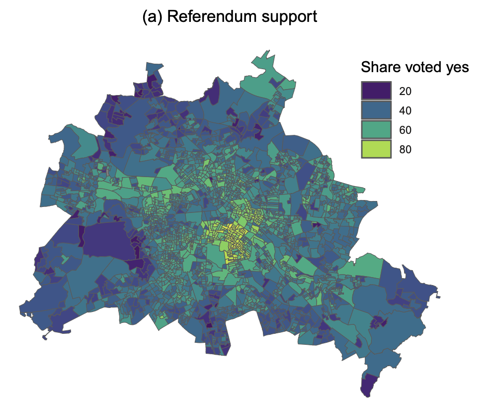

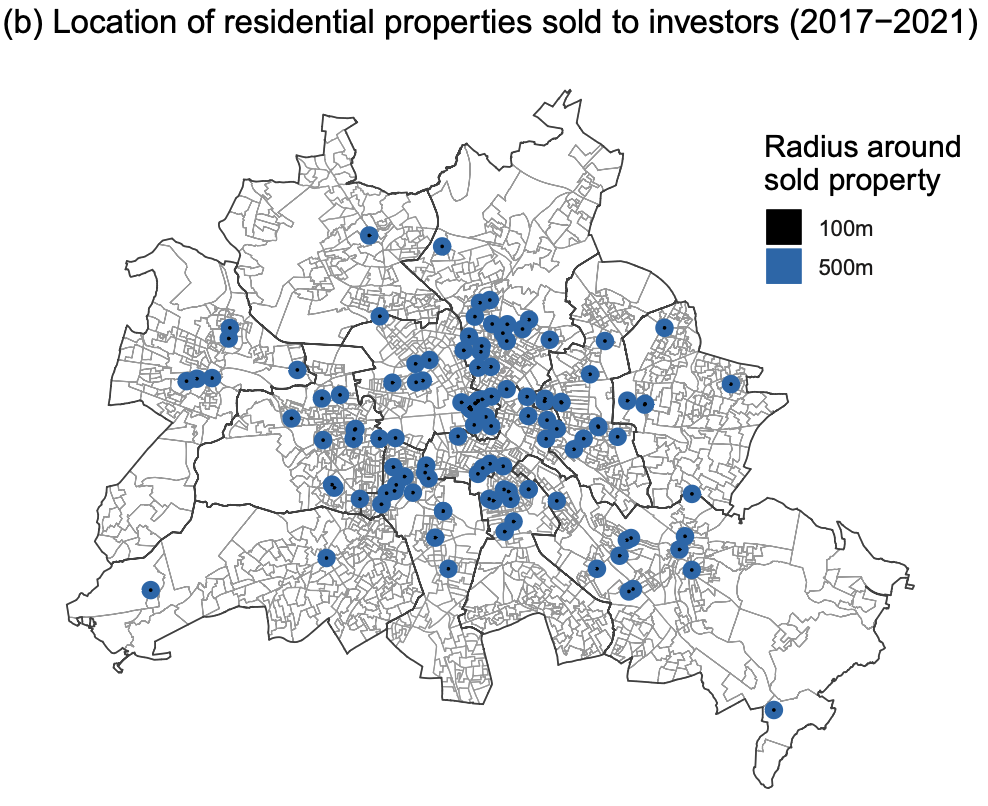

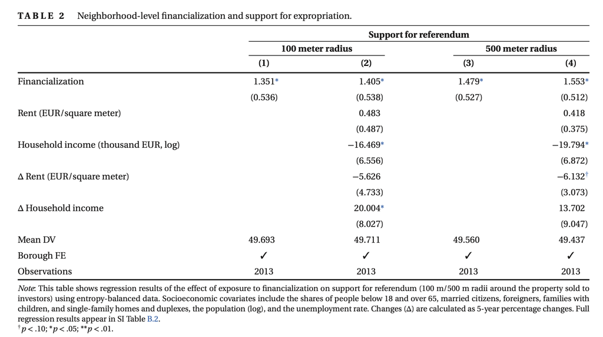

## Ahora interpretemos la parte experimental:

[interactive chart not shown]

## Conjoint (de conjuntos de atributos): Si me das a elegir…

**Descripción**: Tipo de experimento formateado dentro de una encuesta en el que…

- A cada persona se le muestran perfiles (eventos, candidaturas, productos, políticas) formados por varios atributos.
- Los **niveles de cada atributo se asignan al azar**, de modo que ningún atributo queda correlacionado con otro.
- La persona elige entre perfiles o los puntúa. Cada participante repite la tarea varias veces.

**Pros**:

- Estima el **efecto causal de cada atributo** sobre la elección, gracias a la aleatorización.
- Permite **comparar la importancia relativa** de atributos muy distintos, por ejemplo, en el caso de candidatxs, la agenda política frente al origen étnico.
- Reduce el sesgo de deseabilidad social, porque no se pregunta directamente por el motivo de la elección.

**Para qué se utiliza**:

- Marketing: preferencia de consumidores por productos con distintos atributos

## Ejemplos clásicos en ciencia política

- El buen migrante
- El perfecto presidenciable:

[interactive chart not shown]

## Ejemplo: El valor de la democracia

*¿Cómo mediríais qué tipo de estado prefiere la gente?*

- Podemos utilizar los experimentos conjoints para observar qué dimensiones valoramos más de nuestros estados:

[interactive chart not shown]

## Limitaciones de los conjoint

- Hay combinaciones de atributos que dan perfiles poco realistas
- Forzar elegir da lugar, habitualmente a inconsistencias que no se reproducen en comportamientos

**Experimentos de laboratorio**

**Definición**: los participantes acuden a un *entorno controlado* (un laboratorio o aula) donde el investigador manipula una variable, asigna al azar a los sujetos a las condiciones y mide las reacciones de forma inmediata [pensad que antes las encuestas no se realizaban online]

- **Qué se manipula**: un estímulo concreto, como un panfleto editado, un mensaje político, un anuncio de campaña o las reglas de un juego de negociación o de bienes públicos
- **Qué se mide**: actitudes, decisiones o conductas durante la sesión, a veces con instrumentos que no existen en una encuesta (tiempos de respuesta, seguimiento ocular, juegos con pagos reales)

**Pros**

- **Control del entorno**: mismas condiciones, solo cambia lo que manipulamos -> **validez interna** (causalidad)
- **Mecanismos**: podemos medir los pasos intermedios (atención, recuerdo, argumentos en contra) y no solo el resultado final
- **Tratamientos que no existen en la vida real**: podemos crear el estímulo exacto que la teoría exige y mantener constante todo lo demás
- **Coste moderado**+

## Ejemplo: Milgram

[video not shown]

## Ejemplo: Baldassarri y Grossman

[interactive chart not shown]

## Limitaciones

**De las encuestas, en general**

- Las encuestas raramente capturan comportamientos reales, y las decisiones hipotéticas pueden diferir de las reales.
- Los tratamientos de encuesta suelen ser débiles y poco realistas:
  - Estamos expuestos a miles de mensajes de ese tipo a lo largo del día
  - Distan de ser experiencias reales [*baja validez externa*]

## Ejemplo: Barabas y Jerit

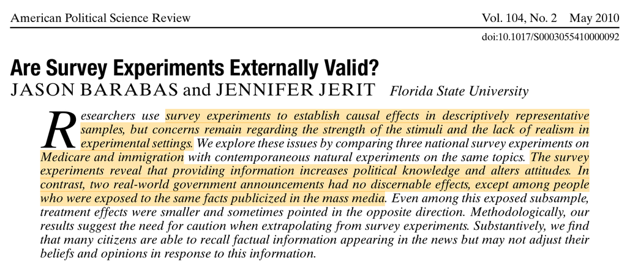

## La “solución”

El *jamón de jabugo* de las CCSS: los **Experimentos controlados aleatorios de campo**

- Entre los miembros de muestra, se controla y aleatoriza su presencia o exposición a un evento, una experiencia, oun proceso que ocurre en la vida real: *La aleatorización* no se da en laboratorios o encuestas, sino *en situaciones del día a día*
- Ejemplos habituales: Campañas de canvassing o get-out-the-vote (GOTV) en elecciones, experimentos de educación, experimentos de salud pública, etc.

## Experimentos de campo (randomized controlled trials)

Método de donde el investigador manipula una variable independiente (como el envío de información electoral, una política pública o un incentivo) en un entorno real y cotidiano, con el fin de medir su efecto causal sobre el comportamiento de los ciudadanos, líderes o instituciones.

- Entorno natural del tratamiento: Se desarrollan fuera del laboratorio, en la vida real.
  - Aleatorización (randomization): Los sujetos o unidades de estudio (individuos, vecindarios, mesas electorales) se dividen al azar en grupo de tratamiento (reciben el estímulo) y grupo de control (no lo reciben).
  - Inferencia causal: Permiten aislar relaciones de causa y efecto con gran validez externa, ya que ocurren en condiciones reales.
- Medir los outcomes/variable dependiente con encuestas, con datos administrativos de comportamientos o decisiones, etc

## Replication: Gerber, Green y Larimer (2008)

**Social pressure and voter turnout** (*APSR* 102(1)).

- 300,000 votantes registrados de Michigan (agrupados en hogares) fueron asignadxs aleatoriamente antes de las primarias de 2006 a 1 de las 4 grupos:

| Condition | Mailing |
| --- | --- |
| Control | Nothing |
| Deber ciudadano | “Voting is a civic duty” |
| Hawthorne | “You are being studied” |
| Vecinxs | Shows your own and your neighbors’ past turnout, and promises an update |

```r
library(sandwich); library(lmtest)

social <- read.csv("https://raw.githubusercontent.com/kosukeimai/qss/master/CAUSALITY/social.csv")
social$messages <- relevel(factor(social$messages), ref = "Control")
social$age <- 2006 - social$yearofbirth

# 1. Balance check: pre-treatment covariates should look alike across arms
aggregate(cbind(primary2004, age, hhsize) ~ messages, data = social, FUN = mean)
```

```
    messages primary2004      age   hhsize
1    Control   0.4003388 49.81355 2.183667
2 Civic Duty   0.3994453 49.65904 2.189126
3  Hawthorne   0.4032300 49.70480 2.180138
4  Neighbors   0.4066647 49.85294 2.187770
```

## Replication: balance y ITT

```r
# Joint F-test of balance on past turnout (should NOT reject)
summary(lm(primary2004 ~ messages, data = social))$fstatistic
```

```
       value        numdf        dendf
2.147596e+00 3.000000e+00 3.058620e+05
```

```r
# 2. ITT: difference in 2006 turnout by assigned condition
m1 <- lm(primary2006 ~ messages, data = social)
coeftest(m1, vcov = vcovHC(m1, type = "HC2"))
```

```
t test of coefficients:

                    Estimate Std. Error  t value  Pr(>|t|)
(Intercept)        0.2966383  0.0010445 283.9984 < 2.2e-16 ***
messagesCivic Duty 0.0178993  0.0025947   6.8984  5.27e-12 ***
messagesHawthorne  0.0257363  0.0026094   9.8628 < 2.2e-16 ***
messagesNeighbors  0.0813099  0.0026918  30.2071 < 2.2e-16 ***
---
Signif. codes:  0 '***' 0.001 '**' 0.01 '*' 0.05 '.' 0.1 ' ' 1
```

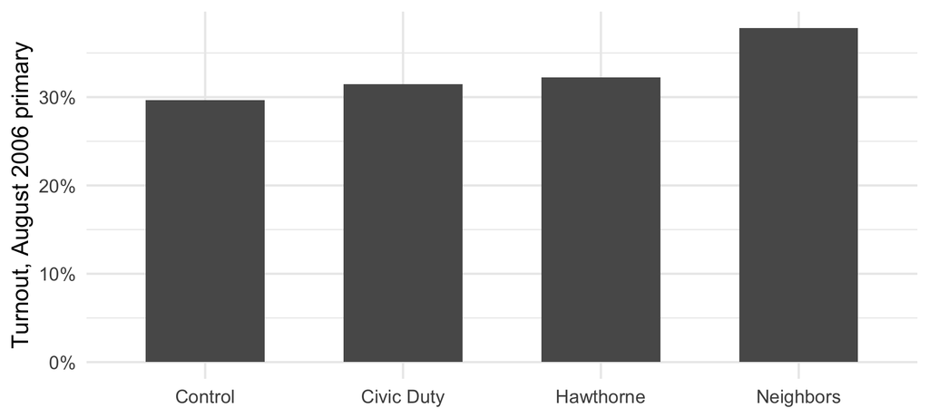

```r
means <- aggregate(primary2006 ~ messages, social, mean)
ggplot(means, aes(x = reorder(messages, primary2006), y = primary2006)) +
  geom_col(width = 0.6) +
  scale_y_continuous(labels = scales::percent) +
  labs(x = NULL, y = "Turnout, August 2006 primary") +
  theme_minimal(base_size = 18)
```

**Note**

Ver el % de participación de lxs vecinxs aumenta la participación en 8 pp respecto al grupo control

## Replication: heterogeneity y control por otrxs variables

```r
# 3. Covariates: improve precision, should not move the estimate if randomization worked
m2 <- lm(primary2006 ~ messages + primary2004 + age + hhsize + sex, data = social)
coeftest(m2, vcov = vcovHC(m2, type = "HC2"))["messagesNeighbors", ]
```

```
     Estimate    Std. Error       t value      Pr(>|t|)
 8.024185e-02  2.627721e-03  3.053667e+01 1.730159e-204
```

```r
# 4. Heterogeneity: is the effect larger among people who voted in 2004?
m3 <- lm(primary2006 ~ messages * primary2004, data = social)
coeftest(m3, vcov = vcovHC(m3, type = "HC2"))
```

```
t test of coefficients:

                                  Estimate  Std. Error  t value  Pr(>|t|)
(Intercept)                     0.23710990  0.00125592 188.7938 < 2.2e-16 ***
messagesCivic Duty              0.01829268  0.00314060   5.8246 5.731e-09 ***
messagesHawthorne               0.02329626  0.00316626   7.3577 1.876e-13 ***
messagesNeighbors               0.06929617  0.00330968  20.9374 < 2.2e-16 ***
primary2004                     0.14869507  0.00216157  68.7904 < 2.2e-16 ***
messagesCivic Duty:primary2004 -0.00065209  0.00535957  -0.1217    0.9032
messagesHawthorne:primary2004   0.00498511  0.00537314   0.9278    0.3535
messagesNeighbors:primary2004   0.02722908  0.00548841   4.9612 7.010e-07 ***
---
Signif. codes:  0 '***' 0.001 '**' 0.01 '*' 0.05 '.' 0.1 ' ' 1
```

## Otro ejemplo

[figure not shown]

## Cilliers et al. (2016): argumento y caso

**Argumento.** Tras un conflicto, los foros comunitarios de reconciliación aumentan el perdón, las redes sociales y las contribuciones a bienes públicos, pero empeoran la salud mental.

**Caso: Sierra Leona**

Guerra civil de 1991 a 2002, con más de 50.000 muertos y 2,6 millones de desplazados

**Intervención: Fambul Tok**

ONG local. Las víctimas relatan, los perpetradores confiesan sin castigo y hay una hoguera de 2 días

**Diseño**

Ensayo aleatorizado con 100 secciones, 200 pueblos y 2383 encuestados, medidos hasta 31 meses después

## Cilliers et al. (2016): diseño experimental

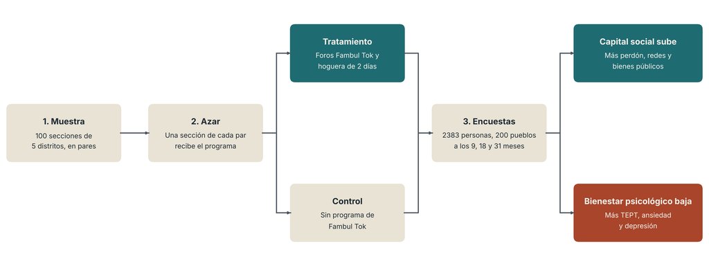

## Cilliers et al. (2016): resultados

Más capital social, pero más estrés postraumático clínico (+36% frente al 8% del control). Los efectos persisten a los 31 meses.

| Resultado | Efecto | Error est. |
| --- | --- | --- |
| Perdón a perpetradores | +0,571** | (0,227) |
| Confianza en excombatientes | +0,177** | (0,079) |
| Redes sociales | +0,099*** | (0,028) |
| Participación comunitaria | +0,058*** | (0,017) |
| Bienes públicos | +0,042* | (0,022) |
| Confianza generalizada | +0,006 | (0,027) |
| Bienestar psicológico | −0,147*** | (0,033) |
| TEPT clínico (probabilidad) | +0,029*** | (0,011) |

Errores estándar entre paréntesis, agrupados por sección. *** p<0,01, ** p<0,05, * p<0,1. En bienestar, un valor negativo indica peor salud mental.

## Otro ejemplo: Balcells et al. (2021)

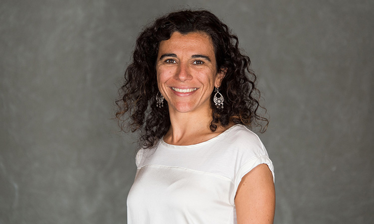

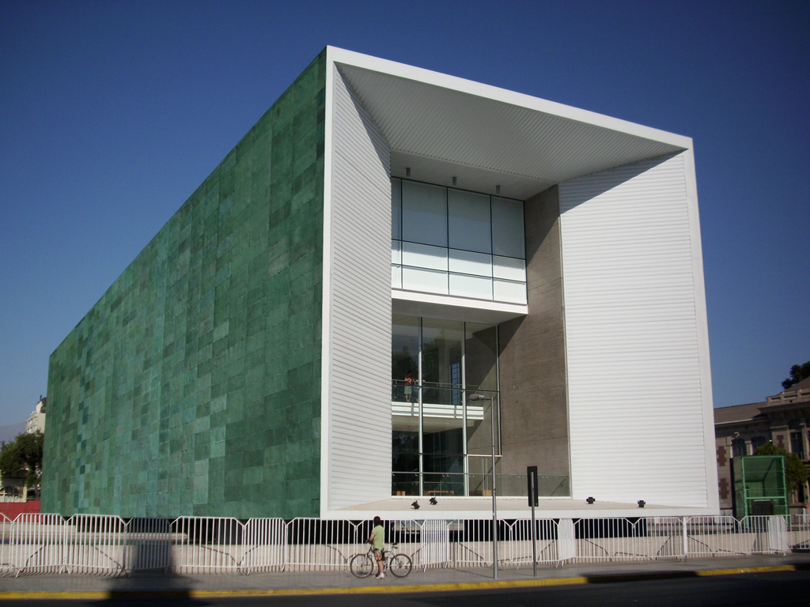

## Ejemplo: Mousa (2020)

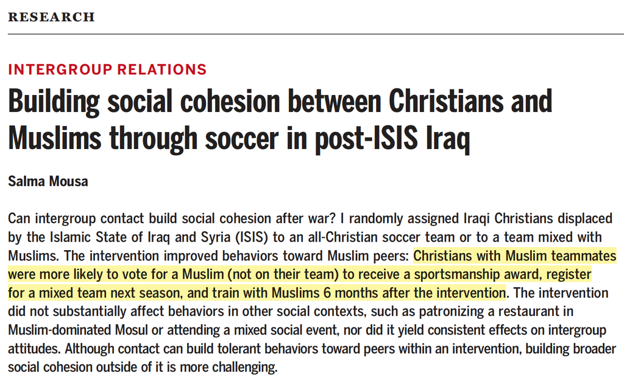

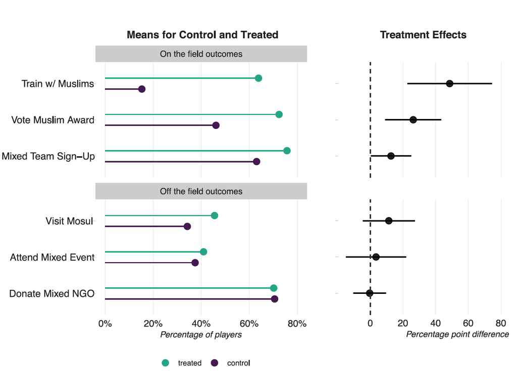

## Pensemos en nuestros trabajos

1. Caso de estudio:
   - Marco temporal y geográfico
   - Social, economic, and political context
2. Estrategia de investigación cualitativa
3. Estrategia de investigación cuantitativa:
- *‘Can we randomize our independent variable?’* Who would be part of the ‘treated’ and the control groups?
- At what level would we measure our dependent variable? Through which measurement instrument?

## También sobre discriminación: volvemos a Alemania

[figure not shown]

[figure not shown]

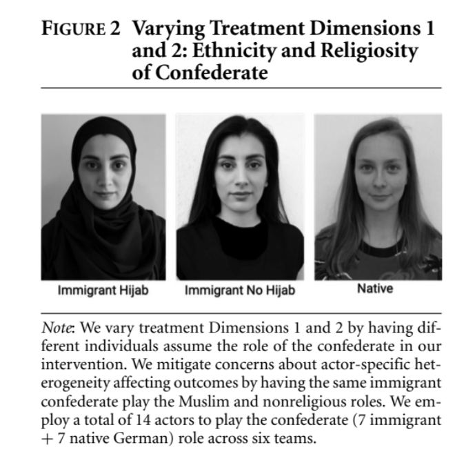

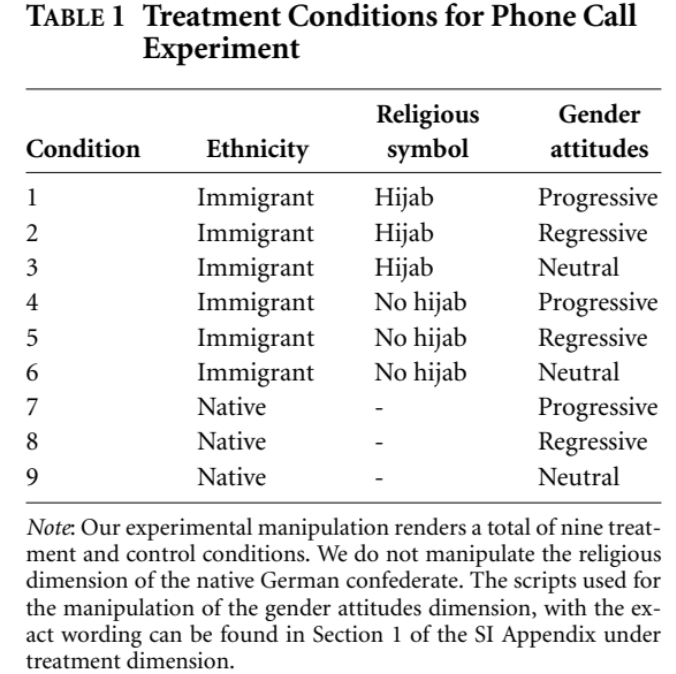

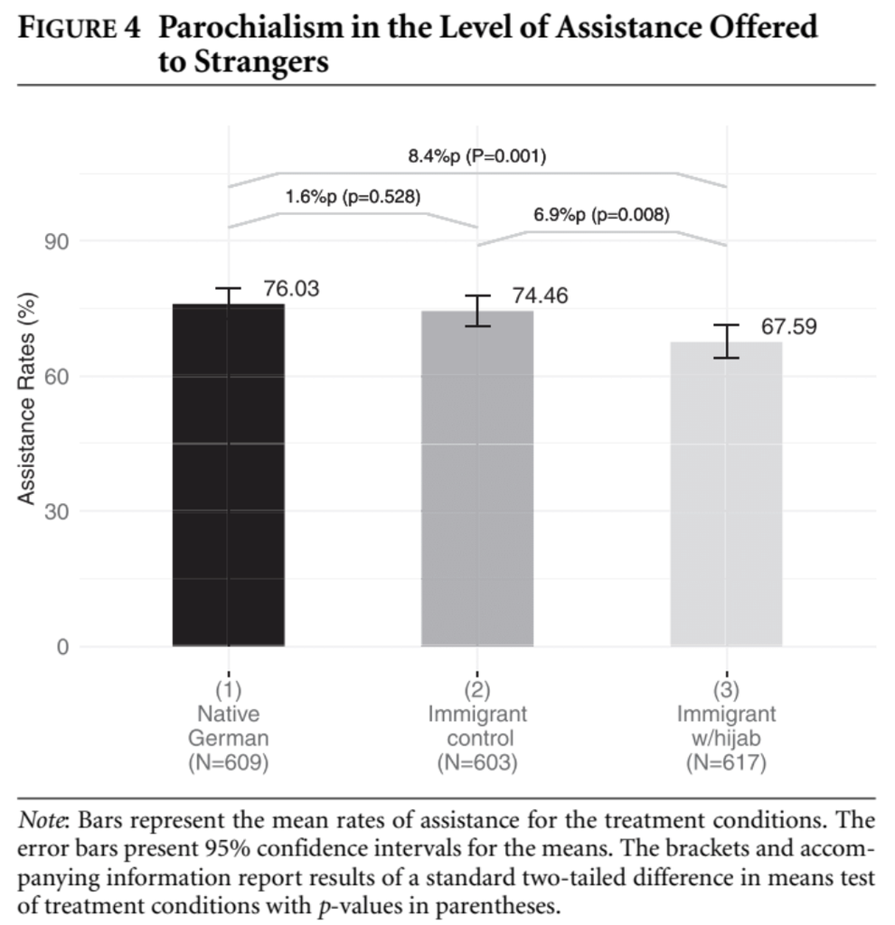

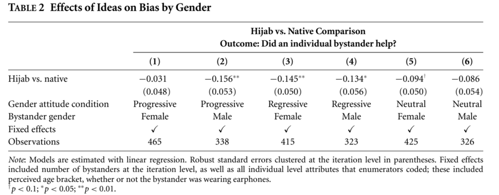

## Asunciones de los Experimentos Controlados Aleatorios de Campo

- ITT (Intention to treat): Todos los tratados están expuestos al tratamiento?
- SUTVA: spillovers o solapamiento entre control y tratado?
- Mecanismos: Por qué se da el efecto? Cuál es la historia?
- Ética? Consentimiento informado?
- Bola extra: [Haas et al.](https://www.dropbox.com/scl/fi/p91krjy485jeljpllc302/haas.pdf?rlkey=jcs5q5fzvw7dnsp5g0mkl6h1d&st=7ibj17jg&dl=0)

## Pero

Los experimentos acostumbran a tener poca validez externa (sí mucha validez interna)

No todo puede ser aleatorizado:

- asesinatos
- muchas políticas públicas
- ganar o perder elecciones
- ser una democracia o no

Por lo tanto, debemos aproximarnos a la lógica experimental, a escenarios donde exista el componente aleatorio pero que el/la investigador/a no tenga el control sobre ello aka. experimento controlado aleatorio natural o diseño casi-experimental

[figure not shown]

## Definiciones

- Experimento controlado aleatorio o RCT: El investigador controla la asignación de las obs al grupo tratado o control (o los valores de la variable independiente) y decide aleatorizarlo
- En un **experimento natural**, el equipo investigador no controla la asignación pero observa que el proceso es plasiblemente aleatorio.

**Ingredientes**

- El tratamieto está asignado por la naturaleza, las instituciones, o una política
- La asignación no está asociada con ninguna variable
- El investigador calla, observa, y analiza/evalúa

**Dos tipos**

- **Randomización real** (loterías, auditorías aleatorias, etc)
- **Casi-randomización** (lindares arbitrarios, etc)

## Nunca tan cerca de ser un artista o un entrenador pokemon

El equipo investigador `encuentra` un experimento salvaje en la naturaleza

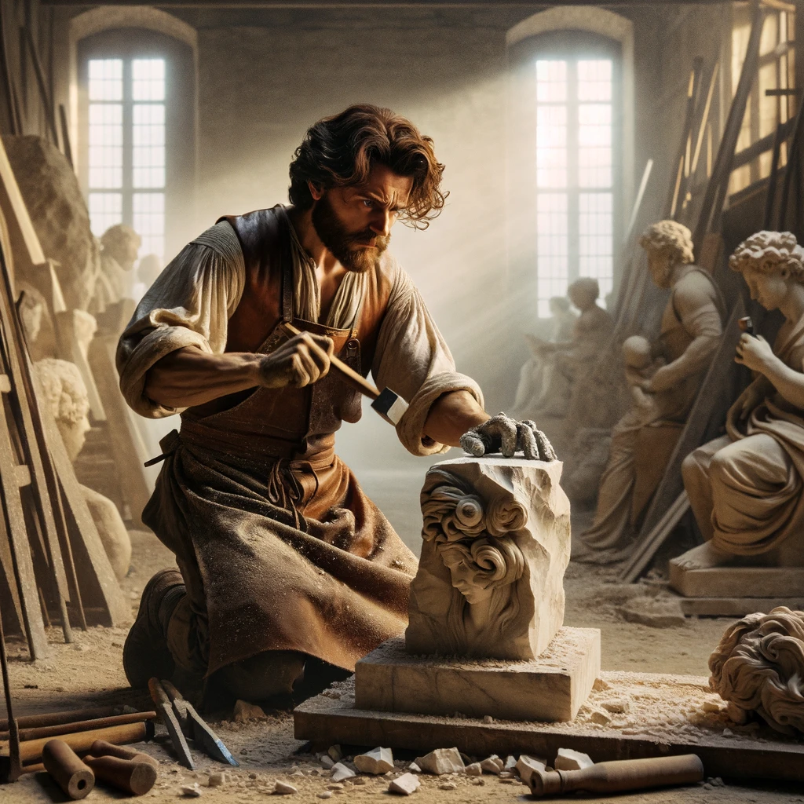

- Instituciones
- Empresas privadas
- La vida

Hace que cierto evento ocurra de manera aleatoria y nosotrxs sólo somos las manos inocentes que lo evalúan.

## All I want for Christmas

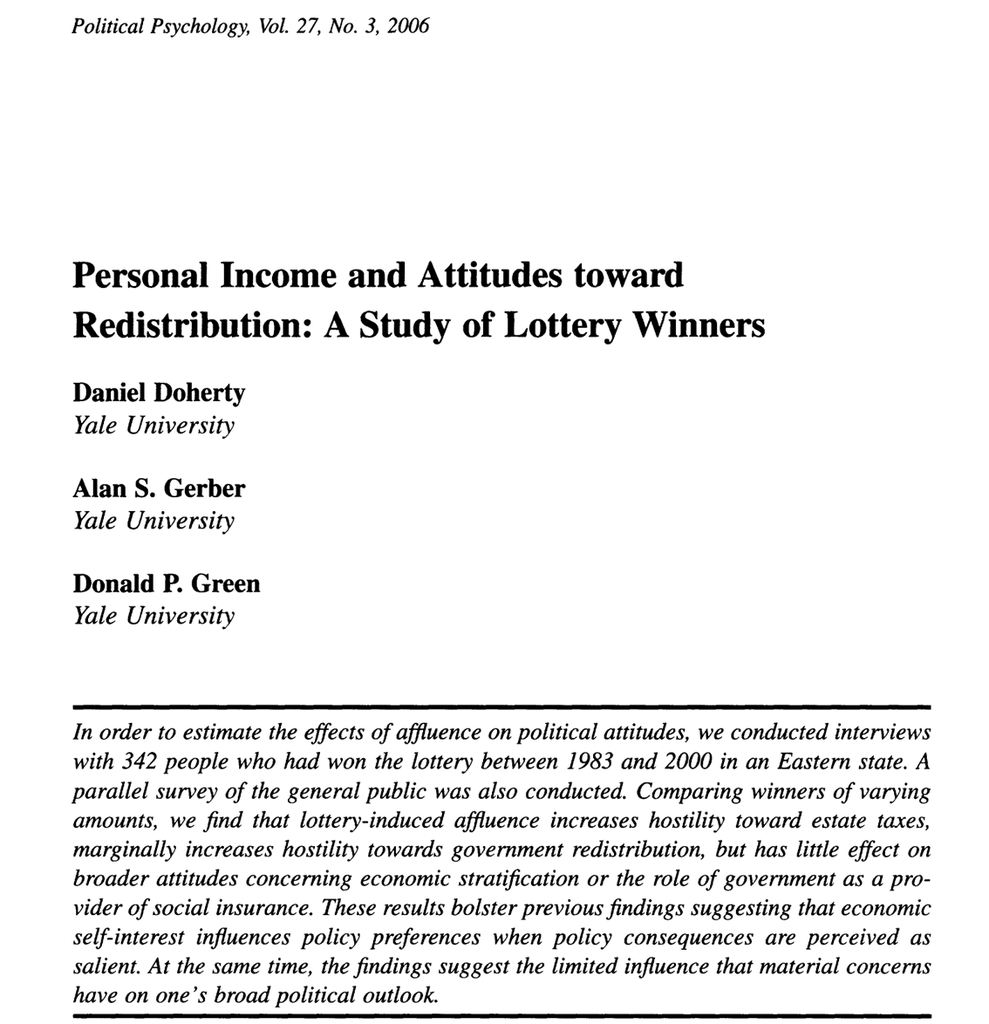

## Finseraas y Kotsadam

[figure not shown]

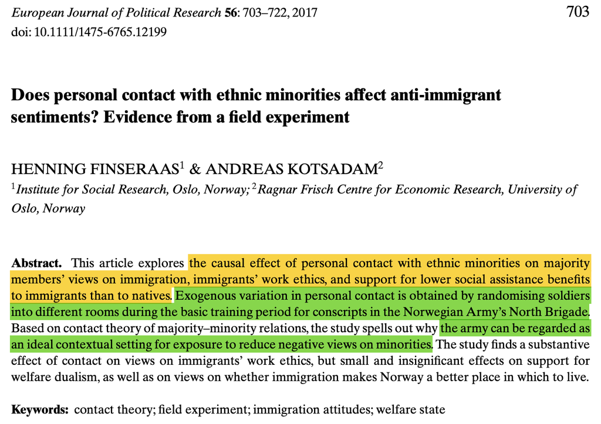

[figure not shown]

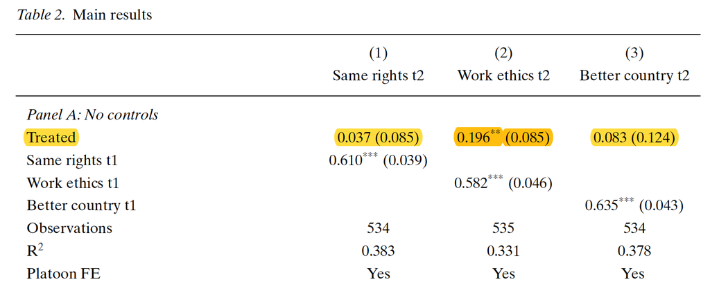

## 29N: qué hay de aleatorio? (I)

[interactive chart not shown]

## 29N: qué es aleatorio? (II)

Podemos romper el sesgo de variable omitida? Podemos aleatorizar la exposición a anuncios de política?

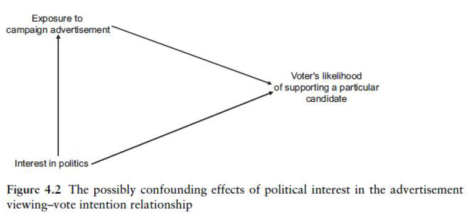

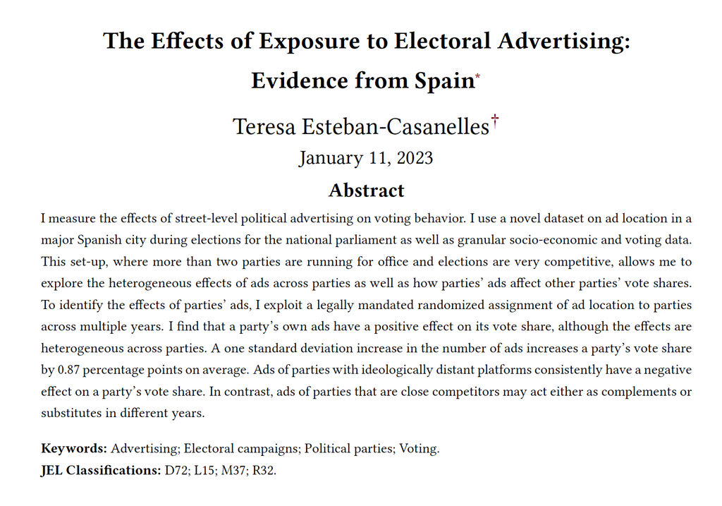

## Esteban-Casanelles: Resultados

[interactive chart not shown]

## Los experimentos naturales también se someten al EXAMEN

| Paso | Pregunta | Problema común |
| --- | --- | --- |
| Asignación | Es aleatoria | Si no hay balance, será por errores de implementación |
| Compliance | De verdad recibieron el tratamienot | **Noncompliance**: ITT $\neq$ tratamiento |
| Interferencias | Se solapan o contaminan el grupo T y el C | **Spillovers** violación de SUTVA |
| Attrition | Vemos la respuesta (VD) en todxs? | Perdemos más obs en el tratado que en el control? |
| **Ética** | Riesgos? | Consentimieto, decepción |

## Cuando no podemos tirar una moneda al aire

habitualmente ponemos un lindar, tope, umbral:

Draft de vietnam:

- Cada fecha de nacimiento era asignada a un número aleatorio secuencial del 1 al 365 en una emisión en televisión nacional.
- Se escogía a los hombres con un número menor del aleatoriamente (lindar) escogido para cada cohorte.
- El lindar se debía a las necesidades militares. Por ejemplo, fue 195 para los nacidos entre 1944 y 1950, 125 para los del 1951, y 95 para los del 1952.
- [Habrías sido seleccionadx?](https://draftvietnam.com/#draftcalculator)

Acceso a cada carrera en España:

- Cada grado tiene un umbral de acceso que depende del número de plazas.

**Este sistema nos va a permitir comparar observaciones, personas, marginalmente por debajo y por encima de los umbrales para establecer cómo ha podido afectar entrar marginalmente en un programa (vs no)**

## Seguiremos con RDD y DiD el próximo lunes

## ¡Nos vemos el próximo lunes! Cualquier duda a smsoler@clio.uc3m.es